# Data 605 HW15: Functions of Several Variables

Please refer to the [Assignment 15 Document](https://github.com/shirley-wong/Data-605/blob/master/Assignment15/hw15_Test%20Builder.pdf).

# 1 Problem Set 1

## 1.1 Question

Find the equation of the regression line for the given points. Round any final values to the nearest hundredth, if necessary.

$$(5.6, 8.8),\,(6.3, 12.4),\,(7, 14.8),\,(7.7, 18.2),\,(8.4, 20.8)$$

## 1.2 Answer

According to the summary, the coefficients are -14.8 (intercept) and 4.257 (x).

Therefore, the regression line is $y=4.26x-14.8$.

```r
x <- c(5.6, 6.3, 7, 7.7, 8.4)
y <- c(8.8, 12.4, 14.8, 18.2, 20.8)

m1 <- lm(y~x)
m1
```

```
##
## Call:
## lm(formula = y ~ x)
##
## Coefficients:
## (Intercept)            x
##     -14.800        4.257
```

```r
summary(m1)
```

```
##
## Call:
## lm(formula = y ~ x)
##
## Residuals:
##     1     2     3     4     5
## -0.24  0.38 -0.20  0.22 -0.16
##
## Coefficients:
##             Estimate Std. Error t value Pr(>|t|)
## (Intercept) -14.8000     1.0365  -14.28 0.000744 ***
## x             4.2571     0.1466   29.04 8.97e-05 ***
## ---
## Signif. codes:  0 '***' 0.001 '**' 0.01 '*' 0.05 '.' 0.1 ' ' 1
##
## Residual standard error: 0.3246 on 3 degrees of freedom
## Multiple R-squared:  0.9965, Adjusted R-squared:  0.9953
## F-statistic: 843.1 on 1 and 3 DF,  p-value: 8.971e-05
```

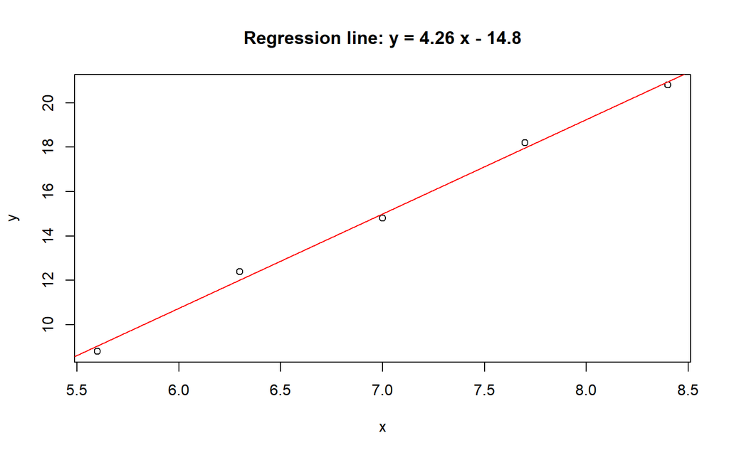

```r
plot(y~x, main="Regression line: y = 4.26 x - 14.8")
abline(m1, col="red")
```

# 2 Problem Set 2

## 2.1 Question

Find all local maxima, local minima, and saddle points for the function given below. Write your answer(s) in the form $(x,y,z)$. Separate multiple points with a comma.

$$f(x,y) = 24x-6xy^{2}-8y^{3}$$

## 2.2 Answer

### 2.2.1 Step 1

**Step 1: Compute the first derivatives and set to 0 to find the critical points.**

$f_{x}=\frac{\partial}{\partial x}(24x-6xy^{2}-8y^{3}) = 24 - 6y^{2} = 0 \Rightarrow y \in \{-2,2\}$

$f_{y}=\frac{\partial}{\partial y}(24x-6xy^{2}-8y^{3}) = -12xy -24y^{2} = 0 \Rightarrow y=0 \;or\; x=-2y$

However, we know that $y \in \{-2,2\}$ from $f_{x}$.

Thus, we have $(x,y) \in {(4,-2), (-4,2)}$ .

Put the two points back to $f$, we have:

$f(4,-2) = 24(4) - 6(4)(4) - 8(-8) = 64$

$f(-4,2) = 24(-4) - 6(-4)(4) - 8(8) = -64$

Therefore, the critical points are $(x,y,z) \in \{(4,-2,64),(-4,2,-64)\}$

### 2.2.2 Step 2

**Step 2: Compute the second derivatives to find if the critical points are local maxima, local minima, or saddle points.**

$f_{xx}=\frac{\partial f_{x}}{\partial x} = \frac{\partial}{\partial x}(24 - 6y^{2}) = 0$

$f_{yy}=\frac{\partial f_{y}}{\partial y} = \frac{\partial}{\partial y}(-12xy -24y^{2}) = -12x-48y$

$f_{xy}=\frac{\partial f_{x}}{\partial y} = \frac{\partial}{\partial y}(24 - 6y^{2}) = -12y$

$f_{yx}=\frac{\partial f_{y}}{\partial x} = \frac{\partial}{\partial x}(-12xy -24y^{2}) = -12y = f_{xy}$

The discriminant $D(f(x,y)) = f_{xx}f_{yy}-f_{xy}f_{yx} = -144y^{2} = -144 \cdot (\pm 2)^{2} = -576 <0$

**Conclusion:**

By the second partial derivative test, both two critical points $(x,y,z) \in \{(4,-2,64),(-4,2,-64)\}$ are saddle points. There is no local maxima or local minina.

# 3 Problem Set 3

## 3.1 Question

A grocery store sells two brands of a product, the “house” brand and a “name” brand.

The manager estimates that if she sells the “house” brand for $x$ dollars and the “name” brand for $y$ dollars, she will be able to sell $(81-21x+17y)$ units of the “house” brand and $(40+11x-23y)$ units of the “name” brand.

Step 1. Find the revenue function $R(x,y)$.

Step 2. What is the revenue if she sells the “house” brand for $2.30 and the “name” brand for $4.10?

## 3.2 Answer

### 3.2.1 Step 1

$R(x,y) = (81-21x+17y)(x) + (40+11x-23y)(y)$

$= 81x - 21x^{2} + 17xy + 40y + 11xy -23y^{2}$

$= 81x - 21x^{2} + 28xy + 40y - 23y^{2}$

### 3.2.2 Step 2

We would need two assumptions to solve this question:

1. The products can be sold and bought back, i.e. the quantity of product can be positive or negative for business purpose.
2. The quantity/unit of products can be in decimal places.

```r
rev <- function(x,y){
  rev <- 81*x - 21*x^2 + 28*x*y + 40*y - 23*y^2
  return(rev)
}
rev(2.3, 4.1)
```

```
## [1] 116.62
```

The revenue is $116.62 if she sells the “house” brand for 102.4 units and the “name” brand for -29 units.

# 4 Problem Set 4

## 4.1 Question

A company has a plant in Los Angeles and a plant in Denver. The firm is committed to produce a total of $96$ units of a product each week.

The total weekly cost is given by $C(x,y)=\frac{1}{6}x^{2}+\frac{1}{6}y^{2}+7x+25y+700$, where $x$ is the number of units produced in Los Angeles and $y$ is the number of units produced in Denver.

How many units should be produced in each plant to minimize the total weekly cost?

## 4.2 Answer

Substituting $y=96-x$ into $C(x,y)$, we have:

$$C(x,y)=\frac{1}{6}x^{2}+\frac{1}{6}y^{2}+7x+25y+700$$

$$C(x,96-x)=\frac{1}{6}x^{2}+\frac{1}{6}(96-x)^{2}+7x+25(96-x)+700$$
$$=\frac{1}{3}x^{2}+1536-32x+7x+2400-25x+700$$
$$=\frac{1}{3}x^{2}-50x+4636$$

Find $x$ and $y$:

$$\frac{\partial C}{\partial x} = \frac{2}{3}x - 50 = 0$$
$$\Rightarrow x=75$$
$$\Rightarrow y=96-75=21$$

Check if this is a local minimum:

$$\frac{\partial C_{x}}{\partial x} = \frac{2}{3} >0$$

As the $C''$ is positive, it proves that the critical point (75,21) is a local minimum.

$$C(75,21) =\frac{1}{3}x^{2}-50x+4636 = 2761$$

$\therefore$ $75$ units should be produced in Los Angeles and $21$ units should be produced in Denver to minimize the total weekly cost to $2,761.

# 5 Problem Set 5

## 5.1 Quetsion

Evaluate the double integral on the given region.

$$\iint_{R}\left ( e^{8x+3y} \right ) dA ;\; R: 2 \leq x \leq 4 \; and \; 2 \leq y \leq 4$$

Write your answer in exact form without decimals.

## 5.2 Answer

$$\int_{2}^{4} \int_{2}^{4} \left ( e^{8x+3y} \right ) dx\;dy$$

$$= \int_{2}^{4} e^{3y} \left [ \frac{e^{8x}}{8} \right ]_{x=2}^{x=4} dy$$

$$=\left [ \frac{e^{32}-e^{16}}{8} \right ] \int_{2}^{4} e^{3y} dy$$

$$=\left [ \frac{e^{32}-e^{16}}{8} \right ] \cdot \left [ \frac{e^{3y}}{3} \right ]_{y=2}^{y=4}$$

$$=\left [ \frac{e^{32}-e^{16}}{8} \right ] \cdot \left [ \frac{e^{12}-e^{6}}{3} \right ]$$

$$=\frac{(e^{32}-e^{16})(e^{12}-e^{6})}{24}$$

$$=\frac{e^{44}-e^{38}-e^{28}+e^{22}}{24}$$